# CFRM 502, Winter 2020

# Instructor: Bahman Angoshtari

# Lecture 9

**Chapter 12:** choosing AR order by information criteria, MA(q) models, ARMA(p,q) models, unit root tests, ARIMA(p,d,q) models

```r
# Setting parameters of the Jupyter notebook
sc = .75
options(repr.plot.width=16*sc,
        repr.plot.height=7*sc,
        repr.plot.pointsize = 13, # Text height in pt
        repr.plot.bg        = 'white',
        repr.plot.antialias = 'gray',
        #nice medium-res DPI
        repr.plot.res       = 300,
        #jpeg quality bumped from default
        repr.plot.quality   = 90,
        #vector font family
        repr.plot.family    = 'serif')
# Vector font family. 'sans', 'serif', 'mono' or a specific one
```

$\newcommand\Fc{\mathscr{F}}$ $\newcommand{\eps}{\varepsilon}$ $\newcommand{\Var}{\operatorname{Var}}$ $\newcommand\Cov{\operatorname{Cov}}$ $\newcommand\Corr{\operatorname{Corr}}$ $\newcommand{\sig}{\sigma}$ $\newcommand{\al}{\alpha}$ $\newcommand{\gam}{\gamma}$ $\newcommand{\Del}{\Delta}$ $\newcommand\tht{\theta}$ $\newcommand\ph{\varphi}$ $\newcommand\om{\omega}$ $\newcommand\Om{\Omega}$ $\newcommand\rb{\bar{r}}$ $\newcommand{\Xb}{\bar{X}}$ $\newcommand{\Yb}{\bar{Y}}$ $\newcommand\Eb{\mathbb{E}}$ $\newcommand\Pb{\mathbb{P}}$ $\newcommand\Qb{\mathbb{Q}}$ $\newcommand\Rb{\mathbb{R}}$ $\newcommand\Zb{\mathbb{Z}}$ $\newcommand\Nb{\mathbb{N}}$ $\newcommand\Av{\textbf{A}}$ $\newcommand\Fv{\textbf{F}}$ $\newcommand\Gv{\textbf{G}}$ $\newcommand\Hv{\textbf{H}}$ $\newcommand\Kv{\textbf{K}}$ $\newcommand\Iv{\textbf{I}}$ $\newcommand\Pv{\textbf{P}}$ $\newcommand\Sv{\textbf{S}}$ $\newcommand\Xv{\textbf{X}}$ $\newcommand\Yv{\textbf{Y}}$ $\newcommand\Zv{\textbf{Z}}$ $\newcommand\av{\mathbf{a}}$ $\newcommand\xv{\mathbf{x}}$ $\newcommand\yv{\mathbf{y}}$ $\newcommand\zv{\mathbf{z}}$ $\newcommand\Cv{\mathbf{C}}$ $\newcommand\mv{\mathbf{m}}$ $\newcommand\nv{\mathbf{n}}$ $\newcommand\pv{\mathbf{p}}$ $\newcommand\sv{\mathbf{s}}$ $\newcommand\wv{\mathbf{w}}$ $\newcommand\Wv{\textbf{W}}$ $\newcommand\betav{{\boldsymbol\beta}}$ $\newcommand\etav{{\boldsymbol\eta}}$ $\newcommand\epsv{{\boldsymbol\varepsilon}}$ $\newcommand\delv{{\boldsymbol\delta}}$ $\newcommand\Lamv{{\boldsymbol\Lambda}}$ $\newcommand\lamv{{\boldsymbol\lambda}}$ $\newcommand\muv{{\boldsymbol\mu}}$ $\newcommand\piv{{\boldsymbol\pi}}$ $\newcommand\ah{\widehat{a}}$ $\newcommand\Pbh{\widehat{\Pb}}$ $\newcommand\phh{\widehat{\varphi}}$ $\newcommand\Ebh{\widehat{\Eb}}$ $\newcommand\Qh{\widehat{Q}}$ $\newcommand\Ih{\widehat{I}}$ $\newcommand\rh{\widehat{r}}$ $\newcommand\pih{\widehat{\pi}}$ $\newcommand\Pih{\widehat{\Pi}}$ $\newcommand\Wh{\widehat{W}}$ $\newcommand\Fh{\widehat{F}}$ $\newcommand\Yh{\widehat{Y}}$ $\newcommand\Yvh{\widehat{\Yv}}$ $\newcommand\Ah{\widehat{\Ac}}$ $\newcommand\uh{\widehat{u}}$ $\newcommand\vh{\widehat{v}}$ $\newcommand\fh{\widehat{f}}$ $\newcommand\hh{\widehat{h}}$ $\newcommand\Bh{\widehat{B}}$ $\newcommand\rhoh{\widehat{\rho}}$ $\newcommand\nuh{\widehat{\nu}}$ $\newcommand\varphih{\widehat{\varphi}}$ $\newcommand\alh{\widehat{\al}}$ $\newcommand\thetah{\widehat{\theta}}$ $\newcommand\betah{\widehat{\beta}}$ $\newcommand\betavh{\widehat{\boldsymbol\beta}}$ $\newcommand\kaph{\widehat{\kappa}}$ $\newcommand\sigh{\widehat{\sigma}}$ $\newcommand\epsh{\widehat{\eps}}$ $\newcommand\epsvh{\widehat{\epsv}}$ $\newcommand\epst{\widetilde{\eps}}$ $\newcommand\muh{\widehat{\mu}}$ $\newcommand\dd{\mathrm{d}}$ $\newcommand\ee{\mathrm{e}}$

# 0. Overview of the lecture

- We start by discussing how the autoregressive order $p$ in AR$(p)$ models can be systematically chosen using information criteria.
- We study the moving average MA(q) models. This class of models can fit time-series which the AR(p) model cannot fit well.
- Next, we study the ARMA(p,q) model, which generalize both the AR and MA models.
- We then study ARIMA(p,d,q) models, which are essentially ARMA(p,q) models applied to the stationary "difference" of a non-stationary process.
- We also discuss unit-root tests to check if a time-series is stationary, and use them to determine the parameter "d" of ARIMA(p,d,q).

# 1. Using AIC/BIC to determine AR order

- In the previous lecture, we learned how to use the sample PACF plot to choose the AR order.
- A second (and more systematic) way of choosing the AR order is by using information criteria
- Since AR(p) models are fitted with MLE, we may define AIC and BIC for them, as follow
  - AIC := $-2\log\big(L(\thetah_\text{ML})\big) + 2\,p$
  - BIC := $-2\log\big(L(\thetah_\text{ML})\big) + \log(n)\,p$
- Recall that Lower values of AIC and BIC are better (lower values correspond to larger likelihood and/or simpler models). Furthermore, BIC is more penalized for model complexity than AIC. Thus, it tends to choose simple models
- To choose the atuoregressive order, we may fit AR(p) models with different $p$ and then choose the one with miminum AIC or BIC values
- We can use the R function `auto.arima()` (in the `forecast` package) to choose the AR order
- Let us consider the BMW stock example from the previous lecture.

```r
library(quantmod) # to use chartSeries and xts
data(bmw,package="evir") # you should install the "evir" package
```

```
Version 0.4-0 included new data defaults. See ?getSymbols.
```

- Here, AIC chooses an AR(2) model, while BIC chooses an AR(1) model

```r
library(forecast) # you need to install the package "forecast"
auto.arima(bmw, max.p = 20, max.q = 0, d = 0, ic = "aic")
auto.arima(bmw, max.p = 20, max.q = 0, d = 0, ic = "bic")
```

```
Series: bmw
ARIMA(2,0,0) with non-zero mean

Coefficients:
         ar1      ar2   mean
      0.0833  -0.0273  3e-04
s.e.  0.0128   0.0128  2e-04

sigma^2 estimated as 0.0002162:  log likelihood=17214.63
AIC=-34421.27   AICc=-34421.26   BIC=-34394.37
```

```
Series: bmw
ARIMA(1,0,0) with zero mean

Coefficients:
         ar1
      0.0816
s.e.  0.0127

sigma^2 estimated as 0.0002164:  log likelihood=17210.94
AIC=-34417.89   AICc=-34417.89   BIC=-34404.44
```

- For the inflation rate example, AIC leads to an AR(8) model, while BIC chooses an AR(6) model

```r
data(Mishkin, package = "Ecdat")
IRate_TS = as.xts(as.ts(Mishkin[,1], start=1950, frequency=12))
IRate = as.vector(Mishkin[,1])
```

```r
auto.arima(diff(IRate), max.p = 20, max.q = 0, d = 0, ic = "aic")
ARfit_BIC = auto.arima(diff(IRate), max.p = 20, max.q = 0, d = 0, ic = "bic")
print(ARfit_BIC)
```

```
Series: diff(IRate)
ARIMA(8,0,0) with zero mean

Coefficients:
          ar1      ar2      ar3      ar4      ar5      ar6      ar7      ar8
      -0.6274  -0.4977  -0.5158  -0.4155  -0.3443  -0.2560  -0.1557  -0.1051
s.e.   0.0456   0.0536   0.0576   0.0606   0.0610   0.0581   0.0543   0.0459

sigma^2 estimated as 8.681:  log likelihood=-1221.2
AIC=2460.4   AICc=2460.78   BIC=2498.15
```

```
Series: diff(IRate)
ARIMA(6,0,0) with zero mean

Coefficients:
          ar1      ar2      ar3      ar4      ar5      ar6
      -0.6057  -0.4554  -0.4558  -0.3345  -0.2496  -0.1481
s.e.   0.0454   0.0522   0.0544   0.0546   0.0526   0.0457

sigma^2 estimated as 8.806:  log likelihood=-1225.67
AIC=2465.33   AICc=2465.56   BIC=2494.69
```

- Note, however, that a model chosen by AIC or BIC is not necessarily a good fit. You should establish that the chosen model is adequate by conducting residual analysis.
- Let us use the `tsdiag()` function to conduct a brief residual diagnostic

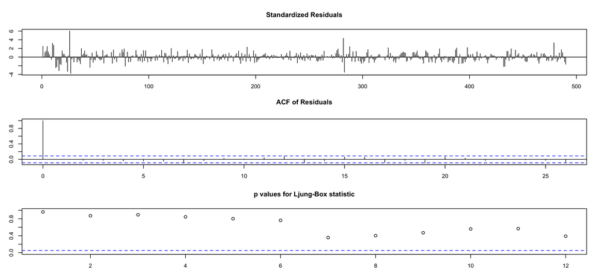

```r
par(mar=c(2,3,4,4))
tsdiag(ARfit_BIC, gof.lag=12)
```

- The model seems adequate. So, we move forward with checking for constant volatility and normality.
- Let us define two functions, `tsdiag_vol()` and `tsdiag_norm()` to check for constant volatility and normality. We will use these functions in subsequent residual analysis.

```r
tsdiag_vol = function(model, lag, fitdf){
    par(mfrow=c(1,2));par(mar=c(3,3,3,3))
    plot(resid(model)**2, type="l", col=1, main = expression(residual^2))
    smoother = loess((resid(model)**2) ~ seq(1,length(resid(model))), span=0.1)
    lines(seq(1,length(resid(model))),fitted(smoother),col=2)
    acf((resid(model)**2), main=expression("sample ACF of "~ residual^2))
    Box.test(resid(model)**2, lag = lag, type = "Ljung-Box", fitdf = fitdf)
}
```

```r
tsdiag_norm = function(model){
    qqnorm(resid(model), datax = TRUE,
       xlab = "normal quantile",
       ylab = "sample quantile of residuals",
       main = "normal probability plot for residuals")
    qqline(resid(model), datax=TRUE, col = 2)
    shapiro.test(resid(model))
}
```

```
	Box-Ljung test

data:  resid(model)^2
X-squared = 77.822, df = 6, p-value = 1.01e-14
```

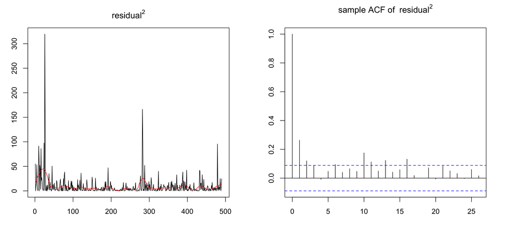

```r
tsdiag_vol(ARfit_BIC, lag=12, fitdf=6)
```

```
	Shapiro-Wilk normality test

data:  resid(model)
W = 0.95705, p-value = 9.456e-11
```

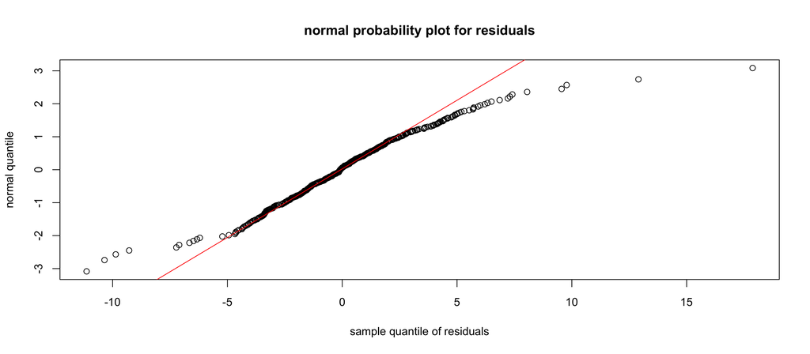

```r
tsdiag_norm(ARfit_BIC)
```

- The results indicate that AR(6) model is adequate. The residuals have non-constant volatility and are not normal, however.
- As we will see soon, there is a simpler model that fits this time-series.

# 2. Moving average (MA) models

- Another way to model stationary processes is by using an MA(q) model

  $r_t = \mu + \eps_{t} + \tht_1 \eps_{t-1} + \tht_2 \eps_{t-2} + \dots + \tht_q \eps_{t-q}$

  where $\tht_1, \dots, \tht_q$ are parameters and $\{\eps_t\}$ is a weak WN$(0, \sig_\eps^2)$
- Using the lag operator $B^\ell \eps_{t}=\eps_{t-\ell}$, we can write the MA(q) model as follows:

\begin{align*} r_t-\mu &= \eps_{t} + \sum_{\ell=1}^q \tht_\ell B^\ell \eps{t}\\ &= \left(1+\sum_{\ell=1}^q \tht_\ell B^\ell\right) \eps_{t} \end{align*}

**Example: MA(1)**

- Consider the MA(1) process $r_t = \mu + \eps_t + \tht \eps_{t-1}$
- $\Eb(r_t) = \Eb(\mu + \eps_t + \tht \eps_{t-1}) = \mu$
- $\Var(r_t) = \Var(\mu + \eps_t + \tht \eps_{t-1}) = \Var(\eps_t) + \tht^2\Var(\eps_{t-1}) = (1+\tht^2)\sig_\eps^2$
- Autocovariance at lag 1

\begin{align*} \gam(1) &= \Cov(r_t, r_{t-1}) = \Cov(\mu + \eps_t + \tht \eps_{t-1}, \mu + \eps_{t-1} + \tht \eps_{t-2})\\ &= \tht \Cov(\eps_{t-1}, \eps_{t-1}) = \tht\,\sig_\eps^2 \end{align*}

- Autocovariance at lag 2

\begin{align*} \gam(2) &= \Cov(r_t, r_{t-2}) = \Cov(\mu + \eps_t + \tht \eps_{t-1}, \mu + \eps_{t-2} + \tht \eps_{t-3})=0 \end{align*}

- Similarly, $0=$ $\gam(3) =$ $ \gam(4) =$ $ \ldots$
- $\rho(1) =$ $\displaystyle \frac{\tht}{1+\tht^2}$, and $\rho(h)$ $=0$ for $h\ge2$
- MA(1) model is always stationary
- MA(1) model has finite memory, in the sense that $\eps_t$ has no effect on $r_{t+2}$, $r_{t+3}, \dots$
- For general MA(q) processes, we have $\Eb(r_t) = \mu$ and $\gam(h) = \rho(h) = 0$ for $h\ge q+1$
- Formulas for $\gam(h)$ and $\rho(h)$, $0\le h\le q$, can be found. They are all time invariant
- MA(q) processes are **always stationary**. They have **finite memory** in the sense that $\eps_t$ has no effect on $r_{t+q+1}, r_{t+q+2}, \dots$

## 2.1. Estimation, model selection, and diagnostics for MA models

- Parameters of MA(q) models are estimated by MLE (maximum likelihood estimation)
- In R, we can use `arima()` with `order=c(0,0,q)` for an MA(q) model
- We can use `auto.arima()` to select MA order q based on AIC or BIC criteria
- Alternatively, we can look at the ACF (not the PACF!) plot of the time series and guess the order q as the point where the ACF drops to zero (can you explain why?)
- The residual diagnostics is similar to the AR(p) model, that is:
  - check that residuals are stationary
  - check that residuals are weak WN
  - check that residuals have constant volatility
  - check that the residual are normal
- Let us fit an MA model to the inflation rate example (recall that AR(6) model was adequate)
- To get an impression of the MA order, we look at the sample ACF plot of the inflation rate
- The ACF does not seem to drop to zero after a certain lag, which means that MA models may not be a good fit either!

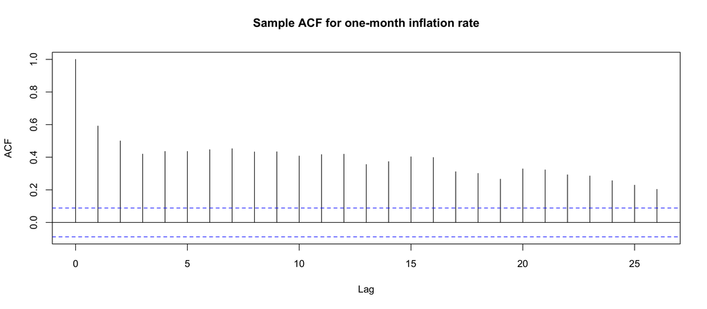

```r
acf(IRate, main="Sample ACF for one-month inflation rate")
```

- The `auto.arima` function indicates 4 MA lags for BIC (9 lags for AIC), which is not a parsimonious model

```r
library(forecast)
auto.arima(IRate, max.p=0, max.q = 20, d=0, ic="aic")
MAFit_BIC = auto.arima(IRate, max.p=0, max.q = 20, d=0, ic="bic")
print(MAFit_BIC)
```

```
Series: IRate
ARIMA(0,0,9) with non-zero mean

Coefficients:
         ma1     ma2     ma3     ma4     ma5     ma6     ma7     ma8     ma9
      0.4223  0.3228  0.1538  0.1779  0.1662  0.1815  0.1813  0.1314  0.1123
s.e.  0.0456  0.0504  0.0536  0.0541  0.0505  0.0436  0.0502  0.0448  0.0420
        mean
      3.9686
s.e.  0.3843

sigma^2 estimated as 9.214:  log likelihood=-1237.11
AIC=2496.22   AICc=2496.78   BIC=2542.39
```

```
Series: IRate
ARIMA(0,0,4) with non-zero mean

Coefficients:
         ma1     ma2     ma3     ma4    mean
      0.4717  0.3742  0.1882  0.1544  3.9772
s.e.  0.0459  0.0489  0.0433  0.0424  0.3066

sigma^2 estimated as 9.777:  log likelihood=-1254.13
AIC=2520.26   AICc=2520.44   BIC=2545.44
```

- As we will see later, the problem is that the time series may not be stationary. To remove non-stationarity, we try working with the difference series $\Delta I_t = I_{t} - I_{t-1}$
- The ACF of the changes in inflation rate indicates an MA(1) or, perhaps, an MA(3), process

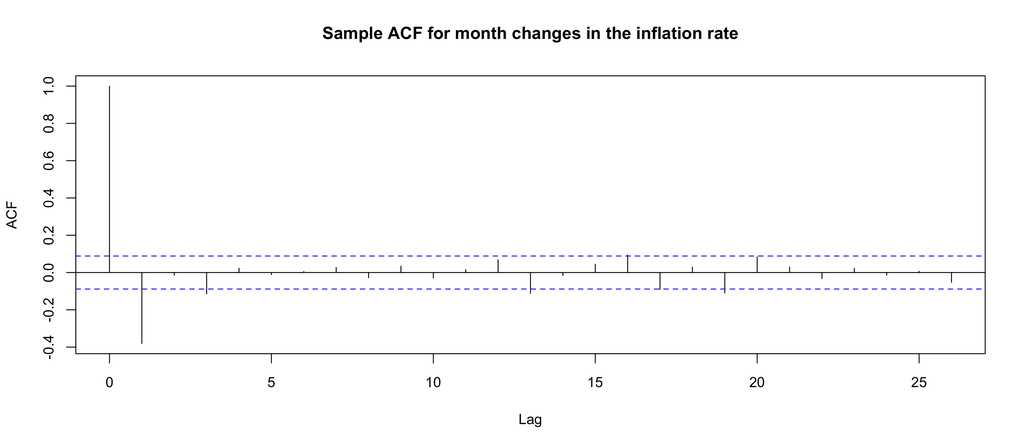

```r
acf(diff(IRate), main="Sample ACF for month changes in the inflation rate")
```

- Using `auto.arima` with BIC, we get the following parsimonious MA(2) model:

  $\Delta I_t = \eps_t -0.6620\, \eps_{t-1} -0.1661\, \eps_{t-2}$, where $(\eps_t)$ is weak WN$(0, 8.63)$

```r
library(forecast)
MAFit_BIC = auto.arima(diff(IRate), max.p=0, max.q = 20, d=0, ic="bic")
print(MAFit_BIC)
```

```
Series: diff(IRate)
ARIMA(0,0,2) with zero mean

Coefficients:
          ma1      ma2
      -0.6620  -0.1661
s.e.   0.0419   0.0407

sigma^2 estimated as 8.63:  log likelihood=-1222.85
AIC=2451.7   AICc=2451.74   BIC=2464.28
```

- Let us conduct a residual diagnostic.
- The MA(2) model seems to be adequate as the residuals are weak WN.

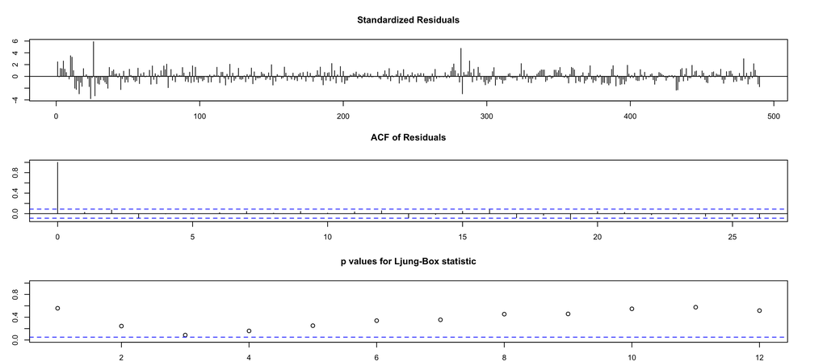

```r
par(mar=c(2,3,4,4))
tsdiag(MAFit_BIC, gof.lag=12)
```

- Residuals$^2$ plot and ACF of Residuals$^2$ indicate non-constant volatility

```
	Box-Ljung test

data:  resid(model)^2
X-squared = 78.786, df = 10, p-value = 8.68e-13
```

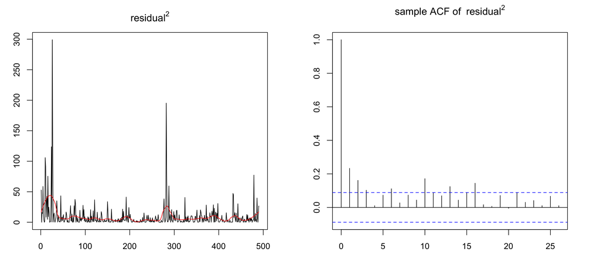

```r
tsdiag_vol(MAFit_BIC, lag=12, fitdf=2)
```

- Finally, the residuals are not normal

```
	Shapiro-Wilk normality test

data:  resid(model)
W = 0.95737, p-value = 1.063e-10
```

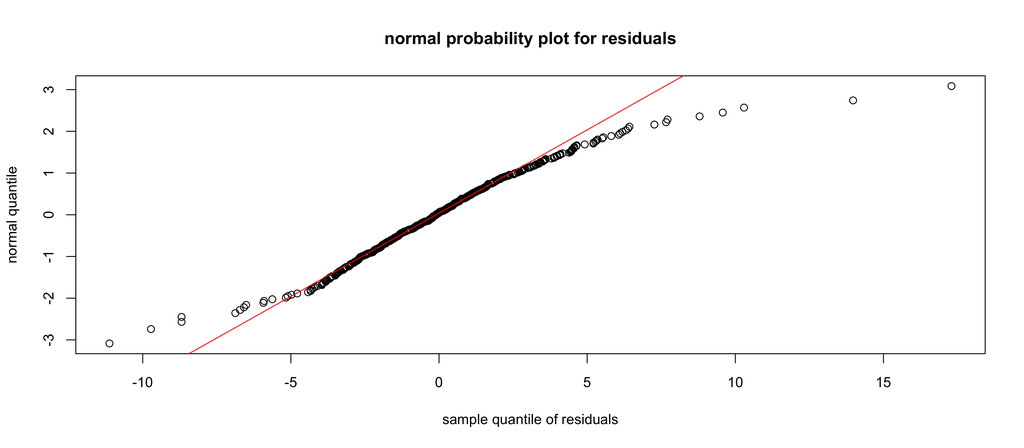

```r
tsdiag_norm(MAFit_BIC)
```

# 3. The ARMA(p,q) model

- An ARMA model is a combination of AR and MA models
- Form of an ARMA(p,q) model:

\begin{align*} r_t-\mu = \underbrace{\ph_1\,(r_{t-1} - \mu) + \dots + \ph_p\,(r_{t-p} - \mu)}_{\text{AR(p)}} + \eps_t + \underbrace{\tht_1 \eps_{t-1} + \dots + \tht_q \eps_{t-1}}_{\text{MA(q)}} \end{align*}

- Here, $\{\eps_t\}$ is weak WN$(0,\sig^2_\eps)$
- Using the lag operator, we have $B^k r_{t}=r_{t-k}$ and $B^\ell \eps_{t}=\eps_{t-\ell}$. So, we can write the ARMA(p,q) model as follows:

\begin{align*} \left(1-\sum_{k=1}^p \ph_k B^k\right)(r_t-\mu) &= \left(1+\sum_{\ell=1}^q \tht_\ell B^\ell\right) \eps_{t}. \end{align*}

## 3.1. ARMA(1,1) model

- To illustrate properties of ARMA model, we consider the ARMA(1,1) model

  $r_t - \mu = \ph(r_{t-1} - \mu) + \eps_t + \tht \eps_{t-1}$, where $\{\eps_t\}$ is weak WN$(0,\sig^2_\eps)$
- Let us find the first two moments of the process
- To find the mean, we take expectation of the ARMA equation:

  $\Eb(r_{t}) - \mu = \ph\,(\Eb(r_{t-1}) - \mu) + \Eb(\eps_t + \tht \eps_{t-1}) = \ph\,(\Eb(r_{t-1}) - \mu)$
- Our goal is to see under what conditions $\{r_t\}$ is stationary
- In such case, we must have $\Eb(r_t) = \Eb(r_{t-1})$
- By assuming the latter equation to hold, we obtain $\Eb(r_{t}) - \mu = \ph\,(\Eb(r_{t}) - \mu)$
- This equation is correct under either of the following two conditions:
  - $\Eb(r_t) = \mu$; or
  - $\ph=1$
- Jumping ahead, $\ph=1$ would imply a "random-walk" behavior, for which the variance is not time-invariant. So, the only acceptable condition for time invariant mean is $\Eb(r_t) = \mu$
- Next, we check the variance

\begin{align*} \Var(r_t) &= \Var(\mu + \ph(r_{t-1} - \mu) + \eps_t + \tht \eps_{t-1})\\ &= \ph^2\Var(r_{t-1}) + \Var(\eps_t) + \tht^2 \Var(\eps_{t-1})\\ &\qquad + 2\,\ph\,\Cov(r_{t-1}, \eps_t) + 2\,\ph\tht\,\Cov(r_{t-1}, \eps_{t-1}) + 2\,\tht\,\Cov(\eps_t, \eps_{t-1}) \end{align*}

- We have $\Var(\eps_t) =$ $ \Var(\eps_{t-1})$ $ = $ $\sig_\eps^2$ and $\Cov(r_{t-1},$ $ \eps_{t})=$ $\Cov(\eps_t, $ $\eps_{t-1})=0$
- Furthermore

\begin{align*} \Cov(r_{t-1}, \eps_{t-1}) &= \Cov(\mu + \ph(r_{t-2} - \mu) + \eps_{t-1} + \tht \eps_{t-2}, \eps_{t-1})\\ &= \ph\,\Cov(r_{t-2}, \eps_{t-1}) + \Cov(\eps_{t-1},\eps_{t-1}) +\tht\,\Cov(\eps_{t-2}, \eps_{t-1})\\ &= \Var(\eps_{t-1}) = \sig^2_\eps \end{align*}

- By substituting these values in the expression for $\Var(r_t)$, we obtain

\begin{align*} \Var(r_t) &= \ph^2\Var(r_{t-1}) + (1 + \tht^2 + 2\ph\tht)\sig_\eps^2 \end{align*}

- Now, assuming that $\{r_t\}$ is weakly stationary, we must have $\Var(r_t)=\Var(r_{t-1})$
- Therefore, for $\{r_t\}$ to be weakly stationary, we must have

  $\Var(r_t) = \ph^2\Var(r_t) + (1 + \tht^2 + 2\ph\tht)\sig_\eps^2$
- This yields: \begin{align*} \Var(r_t) =\displaystyle\frac{(1 + \tht^2 + 2\ph\tht)\sig_\eps^2}{1-\ph^2} \end{align*}
- Note that the right hand side of this equation is positive if and only if $|\ph|<1$ (show this)
- So far, we have shown that to get a time-invariant mean and variance for an ARMA(1,1) process, we must have
  - $|\ph|<1$
  - $\Eb(r_t) = \mu$
  - $\Var(r_t) = \frac{(1 + \tht^2 + 2\ph\tht)\sig_\eps^2}{1-\ph^2}$
- To show stationarity, it remains to check under which conditions the autocovariance $\gam(k) := \Cov(r_t,r_{t-k})$ only depends on $k$
- We have

\begin{align*} \gam(1) = \Cov(r_{t}, r_{t-1}) &= \Cov(\mu + \ph(r_{t-1} - \mu) + \eps_t + \tht \eps_{t-1}, r_{t-1})\\ &= \ph\,\Cov(r_{t-1}, r_{t-1}) + \Cov(\eps_t, r_{t-1}) + \tht\,\Cov(\eps_{t-1}, r_{t-1})\\ &= \ph\,\Var(r_{t-1}) + 0 + \tht\,\sig_\eps^2 \end{align*}

- Assuming

\begin{align*} \Var(r_t) = \frac{(1 + \tht^2 + 2\ph\tht)\sig_\eps^2}{1-\ph^2} \end{align*}

- We obtain:

\begin{align*} \gam(1) = \frac{\ph\,(1 + \tht^2 + 2\ph\tht)\sig_\eps^2}{1-\ph^2} + \tht\,\sig_\eps^2 = \frac{(1+\ph\,\tht)(\ph+\tht)\sig_\eps^2}{1-\ph^2} \end{align*}

- Similarly, for $k\ge2$

\begin{align*} \gam(k) = \Cov(r_{t}, r_{t-k}) &= \Cov(\mu + \ph(r_{t-1} - \mu) + \eps_t + \tht \eps_{t-1}, r_{t-k})\\ &= \ph\,\Cov(r_{t-1}, r_{t-k}) + \Cov(\eps_t, r_{t-k}) + \tht\,\Cov(\eps_{t-1}, r_{t-k})\\ &= \ph\,\Cov(r_{t-1}, r_{(t-1)-(k-1)}) + 0 + 0 \\ &= \ph\,\gam(k-1) =\ph^{k-1}\,\gam(1) = \frac{\ph^{k-1}\,(1+\ph\,\tht)(\ph+\tht)\sig_\eps^2}{1-\ph^2} \end{align*}

- Let us summarize our findings for an ARMA(1,1) processes

  $r_t - \mu = \ph(r_{t-1} - \mu) + \eps_t + \tht \eps_{t-1}$, $\{\eps_t\}\sim$ weak WN$(0,\sig^2_\eps)$
- The process is stationary if
  - $|\ph|<1$
  - $\Eb(r_0) = \mu$
  - $\Var(r_0) = $ $(1 + \tht^2 + 2\ph\tht)$ $\sig_\eps^2 $ $/ (1-\ph^2)$
- If these conditions hold, we have
  - $\Eb(r_t)=\mu$
  - $\Var(r_t) = $ $(1 + \tht^2 + 2\ph\tht)\sig_\eps^2 $ $/ (1-\ph^2)$
  - $\gam(k) =$ $ \Cov(r_{t}, r_{t-k}) =$ $\ph^{k-1}\,(1+\ph\,\tht)$ $(\ph+\tht)\sig_\eps^2$ $/(1-\ph^2)$

**General stationarity condition for ARMA(p,q) processes**

- An ARMA(p,q) process

  $r_t-\mu = \ph_1\,(r_{t-1} - \mu) + \dots + \ph_p\,(r_{t-p} - \mu) + \eps_t + \tht_1 \eps_{t-1} + \dots + \tht_q \eps_{t-1}$

  is stationary if the characteristic equation

  $1 - \ph_1\,x -\ph_2\,x^2 - \dots -\ph_p\,x^p = 0$

  does not have a unit root
- In other words, an ARMA(p,q) model is stationary if and only if its autoregressive part is stationary

## 3.2. Estimation, model selection, and diagnostics for ARMA models

- Estimation, model selection and diagnostics are very similar to AR and MA models
- Let us illustrate by using the inflation rate data

```r
FitARMA_BIC = auto.arima(diff(IRate), max.p=20, max.q = 20, d=0, ic="bic")
print(FitARMA_BIC)
```

```
Series: diff(IRate)
ARIMA(1,0,1) with zero mean

Coefficients:
         ar1      ma1
      0.2383  -0.8772
s.e.  0.0550   0.0269

sigma^2 estimated as 8.587:  log likelihood=-1221.62
AIC=2449.25   AICc=2449.29   BIC=2461.83
```

- We get the following ARMA(1,1) model:

  $\Delta I_t = 0.2383\,\Delta I_{t-1} + \eps_t -0.8772\, \eps_{t-1}$, where $(\eps_t)$ is weak WN$(0, \sig_\eps^2=8.587)$
- Residuals are weak WN, so, the model is adequate.

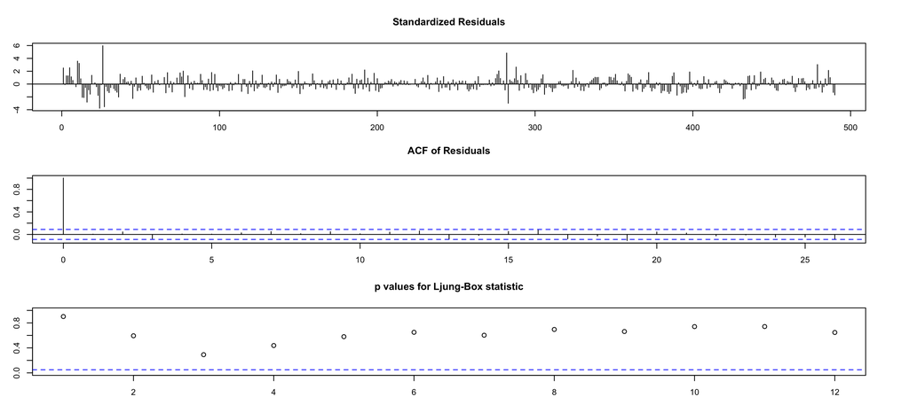

```r
par(mar=c(2,3,4,4))
tsdiag(FitARMA_BIC, gof.lag=12)
```

- Volatility is not constant.

```
	Box-Ljung test

data:  resid(model)^2
X-squared = 73.202, df = 10, p-value = 1.064e-11
```

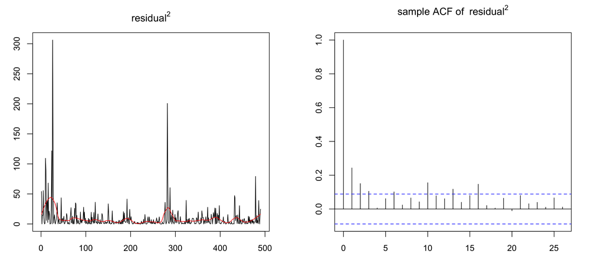

```r
tsdiag_vol(FitARMA_BIC,lag=12, fitdf=2)
```

- Residuals are not normal

```
	Shapiro-Wilk normality test

data:  resid(model)
W = 0.95469, p-value = 4.058e-11
```

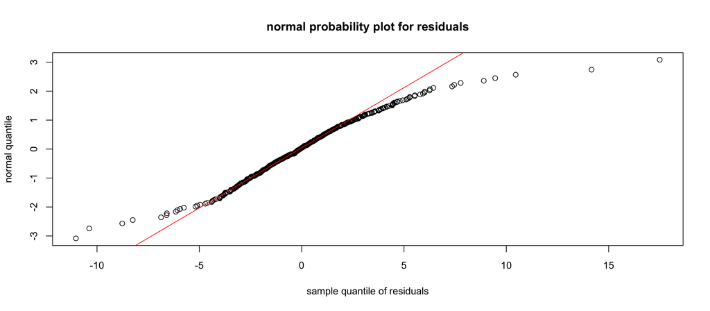

```r
tsdiag_norm(FitARMA_BIC)
```

# 4. ARIMA(p,d,q) Models

- Many non-stationary financial time series become stationary after differencing. For example, log prices are usually non-stationary, but their difference (log returns) are stationary. We call such processes **"integrated"**
- For a process $r=\{r_t\}$, the process $\Del r$ is given by $\Del r_{t} = r_{t} - r_{t-1}$
- This operator is the `diff()` function in R
- The second difference $\Del^2 r_t$ is defined as $\Del(\Del r_t)$
- Similarly, the d-th difference is $\Del^d r_t = \underbrace{\Del\dots\Del}_{\text{d times}} r_t$

**Definition:** We say that process $\{r_t\}$ is integrated of order d, denoted by $I(d)$, if $\{\Del^d r_t\}$ is a weakly stationary process

- Let us see how integrated process look like by simulating them
- First we simulated an AR(1) process, let us call it $X=\{X_t\}$

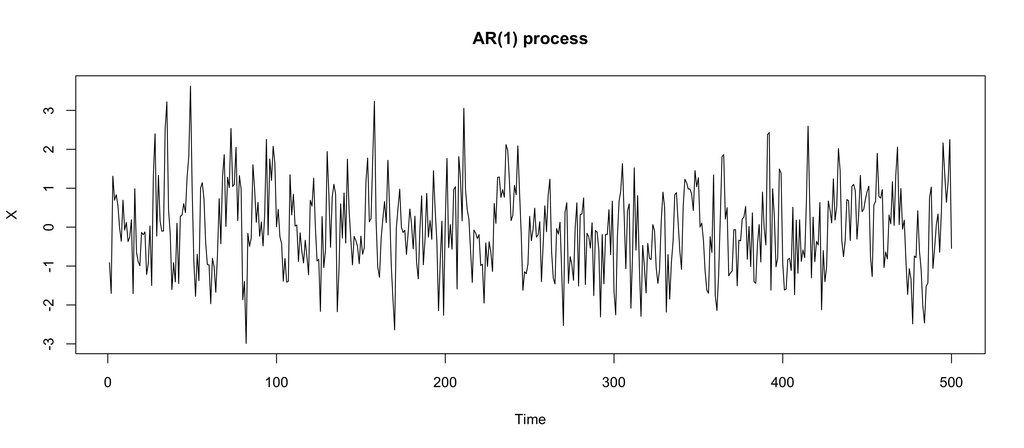

```r
set.seed(4631)
X = arima.sim(n = 500, list(ar = c(0.4)))
plot(X,type="l",lwd=1,main="AR(1) process")
```

- Next, we define an I(1) process by $Y_0=0$ and $Y_t = Y_{t-1} + X_t$
- Note that $\Del Y_t = X_t$
- An $I(1)$ process has a **random walk behavior**

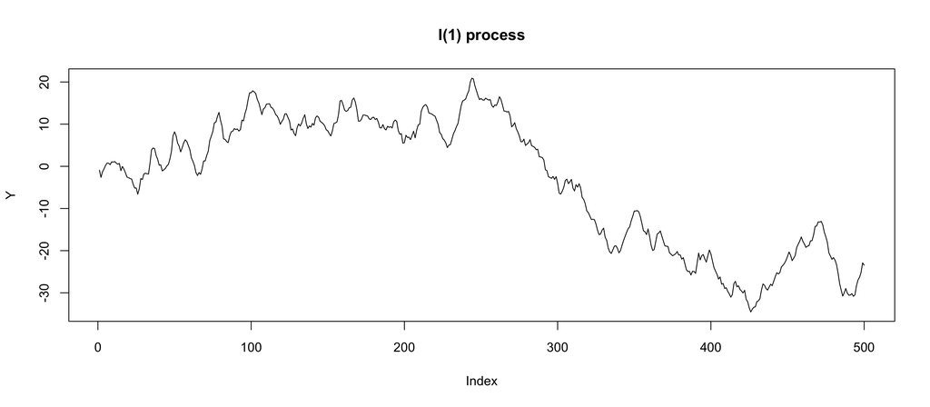

```r
Y = cumsum(X)
plot(Y,type="l",lwd=1,main="I(1) process")
```

- Finally, we define an $I(2)$ process by $Z_0=0$, $Z_t = Z_{t-1} + Y_t$
- Note that $\Del^2 Z_t = X_t$
- $I(2)$ processes have **momentum**

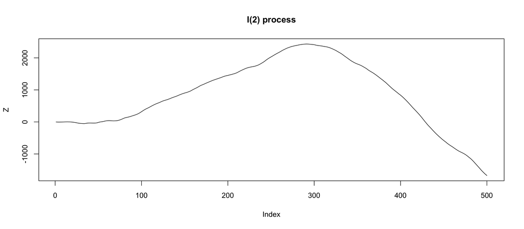

```r
Z = cumsum(Y)
plot(Z,type="l",lwd=1,main="I(2) process")
```

- ARMA models are used for modeling stationary time series
- However, we may also use ARMA models for a non stationary I(d) process, by modeling their d-th difference
- This is the main idea behind `ARIMA` (autoregressive integrated moving average) models

**Definition:** A process is ARIMA(p,d,q) if its d-th difference is an ARMA(p,q) process

  $I_t = 1.2074\, I_{t-1} - 0.2237\, I_{t-2} + \eps_t -0.8573\,\eps_{t-1}$

```r
Fit = auto.arima(IRate, max.p=20, max.q = 20, d=0, ic="bic")
print(Fit)
```

```
Series: IRate
ARIMA(2,0,1) with non-zero mean

Coefficients:
         ar1      ar2      ma1    mean
      1.2074  -0.2237  -0.8573  4.1068
s.e.  0.0587   0.0551   0.0337  1.0692

sigma^2 estimated as 8.533:  log likelihood=-1221.52
AIC=2453.03   AICc=2453.16   BIC=2474.02
```

- To determin if the ARMA process is stationary, we check the **estimated** characteristic equation

  $1 - 1.2074\, x + 0.2237\,x^2=0$
- The roots are both real and greator than one, so, there is no unit root and the process is stationary

```r
polyroot(c(1, -coef(Fit)[["ar1"]], -coef(Fit)[["ar2"]]))
```

1. 1.02153890026532+0i

2. 4.37685586282075-0i

- Looking back at the model estimate, we see that the first AR coefficient is 1.2074 with standard error of 0.0587
- Let see what happens if we change the first AR coefficient by 1 standard error

```r
polyroot(c(1, -1.25, -coef(Fit)[["ar2"]]))
```

1. 0.967476385764474+0i

2. 4.6214342701427-0i

- Now there is a unit root, the process is no longer stationary!
- The method above is not taking the randomness of the estimated values of the coefficients into account.
- We need more systematic statistical tests for stationarity. Such tests are called **"unit root tests"**
- There are three common unit root tests
  - **ADF (augmented Dickey-Fuller) test:** usually tests $H_0:$ there is a unit root, versus, $H_1:$ the process is stationary
  - **PP (Phillips-Perron) test:** same as ADF test
  - **KPSS (Kwiatkowski-Phillips-Schmidt-Shin) test:** The opposite of ADF and PP. Test $H_0:$ the process is stationary, versus $H_1:$ there is a unit root
- The unit root tests may disagree. For example, ADF and PP may indicate that the process is stationary, while KPSS indicates that the process is non-stationary
- The ADF and PP test indicate that the inflation rate time series is stationary

```r
library(tseries)
adf.test(IRate)
pp.test(IRate)
```

```
	Augmented Dickey-Fuller Test

data:  IRate
Dickey-Fuller = -3.8651, Lag order = 7, p-value = 0.01576
alternative hypothesis: stationary
```

```
	Phillips-Perron Unit Root Test

data:  IRate
Dickey-Fuller Z(alpha) = -248.75, Truncation lag parameter = 5, p-value
= 0.01
alternative hypothesis: stationary
```

- The KPSS test indicates non-stationarity

```r
kpss.test(IRate)
```

```
	KPSS Test for Level Stationarity

data:  IRate
KPSS Level = 2.51, Truncation lag parameter = 5, p-value = 0.01
```

- Since the tests disagree, we take a difference and run the tests again

```r
adf.test(diff(IRate))
```

```
	Augmented Dickey-Fuller Test

data:  diff(IRate)
Dickey-Fuller = -12.804, Lag order = 7, p-value = 0.01
alternative hypothesis: stationary
```

```r
pp.test(diff(IRate))
```

```
	Phillips-Perron Unit Root Test

data:  diff(IRate)
Dickey-Fuller Z(alpha) = -545.13, Truncation lag parameter = 5, p-value
= 0.01
alternative hypothesis: stationary
```

```r
kpss.test(diff(IRate))
```

```
	KPSS Test for Level Stationarity

data:  diff(IRate)
KPSS Level = 0.032167, Truncation lag parameter = 5, p-value = 0.1
```

- Now they agree that the changes in the inflation rate is stationary
- To estimate an ARIMA model, one starts by identifying d
- For this, apply the unit root test to the times series itself. If the test indicate stationarity, then d=0
- If not, then keep differencing the process until the unit root tests agree on stationarity of the differenced process. Choose the number of differencing needed to achieve stationary as the integration order d
- Once the integration order is determined, fit an ARMA(p,q) model to the d-th difference of the time series
- This whole processes is automated in R, by using the `auto.arima()` function
- Diagnostics for an ARIMA model is the same as that of an ARMA model
- `auto.arima()` function suggest an ARIMA(1,1,1) model for the inflation rate time-series. This is consistent with what we found before.

```r
FitARIMA_BIC = auto.arima(IRate, max.p=20, max.q = 20, max.d=2, ic="bic")
print(FitARIMA_BIC)
```

```
Series: IRate
ARIMA(1,1,1)

Coefficients:
         ar1      ma1
      0.2383  -0.8772
s.e.  0.0550   0.0269

sigma^2 estimated as 8.587:  log likelihood=-1221.62
AIC=2449.25   AICc=2449.29   BIC=2461.83
```